# Perceived Action Boundary Analysis

## 1 Setting up the environment

### 1.1 Packages

We are using the `MixedPsy` package to fit the psychometric functions. See: https://www.biorxiv.org/content/10.1101/2022.06.20.496855v1

```r
pacman::p_load(
  tidyverse,  # Data manipulation and visualization
  glue,       # String interpolation
  here,       # File path manipulation
  MixedPsy,   # Mixed factorial design analysis
  lmerTest,   # ANOVA for linear mixed effects models
  performance,# model testing
  afex,       # Factorial experiment analysis
  ggtext,     # Formatted text in ggplot2
  ggrain,     # Sediment grain size analysis
  ggpp,       # Enhanced ggplot2 features
  sdamr       # Marine research data analysis
)

#----- custom plot theme

text_size = 14
strip_bg_color = "grey20"
strip_text_color = "white"


# custom APA plot
theme_apa <- function(){
  theme(
    plot.title = element_markdown(size = text_size), # Adjust the size as needed
    #legend.position = "right",
    legend.text = element_markdown(size = text_size),
    legend.title = element_text(face="bold", size = text_size + 2),
    legend.key = element_blank(),
    plot.caption = element_text(hjust = 0),
    axis.text.x = element_text(size = text_size),
    axis.text.y = element_text(size = text_size),
    axis.title.x = element_markdown(size = text_size+2, face = "bold"),  # Bolds x title
    axis.title.y = element_markdown(size = text_size+2, face = "bold"),  # Bolds y title
    axis.title.x.top = element_markdown(size = text_size+2, face = "bold"),  # Bolds x title
    axis.title.y.right = element_markdown(size = text_size+2, face = "bold"),  # Bolds y title
    strip.text = element_text(size = text_size+2, face = "bold", color = strip_text_color),
    strip.background = element_rect(fill = strip_bg_color, color = "black", size = 1),    panel.grid.major = element_blank(),
    panel.grid.minor = element_blank(),
    panel.background = element_rect(fill = "white"), # Set the background color to white
    axis.line = element_line(color = "black") # prevents axes from disappearing
)}
rawdata_folder <- here("rawdata")
```

### 1.2 loading in the data

```r
pressure_df <- read_csv(here(rawdata_folder, "combined_pressure_selection_data.csv"))

nonpressure_df <- read_csv(here(rawdata_folder, "combined_non_pressure_selection_data.csv"))

all_data_raw_df <- bind_rows(nonpressure_df, pressure_df)

DT::datatable(all_data_raw_df)
```

|  | group | part_num | direction_block | session | trial_num | ratio | choice | decision | correct_through | ineficient_around | risky_bump | correct_around |
| --- | --- | --- | --- | --- | --- | --- | --- | --- | --- | --- | --- | --- |
| 1 | Nonpressure Group | 105 | 1 | Session 1 | 1 | 0.6 | 0 | 0 | 1 | 0 | 0 | 0 |
| 2 | Nonpressure Group | 105 | 1 | Session 1 | 2 | 0.7 | 0 | 0 | 1 | 0 | 0 | 0 |
| 3 | Nonpressure Group | 105 | 1 | Session 1 | 3 | 0.8 | 0 | 0 | 1 | 0 | 0 | 0 |
| 4 | Nonpressure Group | 105 | 1 | Session 1 | 4 | 0.9 | 1 | 1 | 0 | 1 | 0 | 0 |
| 5 | Nonpressure Group | 105 | 1 | Session 1 | 5 | 1 | 1 | 1 | 0 | 1 | 0 | 0 |
| 6 | Nonpressure Group | 105 | 1 | Session 1 | 6 | 1.1 | 0 | 1 | 0 | 0 | 0 | 1 |
| 7 | Nonpressure Group | 105 | 1 | Session 1 | 7 | 1.2 | 0 | 1 | 0 | 0 | 0 | 1 |
| 8 | Nonpressure Group | 105 | 1 | Session 1 | 8 | 1.3 | 0 | 1 | 0 | 0 | 0 | 1 |
| 9 | Nonpressure Group | 105 | 1 | Session 1 | 9 | 1.4 | 0 | 1 | 0 | 0 | 0 | 1 |
| 10 | Nonpressure Group | 105 | 2 | Session 1 | 10 | 1.4 | 0 | 1 | 0 | 0 | 0 | 1 |

[output cut: 7046 more lines]

### 1.3 adding direction label

Regarding ratios: The closing gap between NPCs may be described by a minimum speed required to pass (Vmin) that is equal to the speed capacity of the actor (Vcap) or by a Vmin/Vcap ratio equal to 1; ratios below 1 were passable and those greater than 1.0 were not passable.

The predictor “direction” has two scenarios: (1) ascending ratio and (2) descending ratio. However, the “ratio” is inversely related to the gap width. In the ascending scenario, the affordance for passing through the gap is being diminished over successive trials, while in the descending scenario, the affordance for passing through the gap is emerging.

Therefore, for each block, if the starting ratio is greater than the ending ratio (i.e., descending), then the direction is “Affordance emerging”. Otherwise, the direction is “Affordance disappearing”.

```r
all_data_raw_df <-
  all_data_raw_df %>%
  # split by group, then participant, then direction_block
  group_by(group, part_num, direction_block) %>%
  # perform the following within each direction_block
  mutate(starting_ratio = first(ratio),
         ending_ratio = last(ratio),
         direction = ifelse(starting_ratio > ending_ratio,
                            # starts at 1.4 and goes to 0.6
                            "Affordance emerging",
                            "Affordance disappearing"),
         variance= var(decision) # get the variance of the decision
                  )
```

### 1.4 filtering blocks

Filtering out blocks with low variance. This is done to remove blocks where the participant is not changing their behavior.

```r
# getting rid of zero variance as it means no change in behavior
filtered_data_raw_df <- all_data_raw_df%>%
  filter(variance > .15)
```

## 2 Individual perceptual boundary example

We take as the perceptual boundary the point at which the participant is equally likely to choose either option (using a psychmetric function). We will take this value and use it as the dependent variable in a linear mixed effects model.

I’ll be using the `MixedPsy` package to calculate the PAB for each participant. The package requires the data to be in a specific format, so I’ll need to do some data wrangling first.

```r
response_pab_df <-
  filtered_data_raw_df %>%
  group_by(group, part_num, direction, ratio, session) %>%
  summarise(
    total = n(), #why this total isn't 8 for each ratio for each particip?
    through = sum(decision == "0"), # I corrected this!
    around = sum(decision == "1"),
  )


response_prob_df <-
  filtered_data_raw_df %>%
  group_by(group, part_num, direction, ratio, session) %>%
  summarise(
    choice_prob = mean(choice),
        #correct_through_prob = mean(correct_through),
        #risky_bump_prob = mean(risky_bump),
        #correct_around_prob = mean(correct_around),
        #ineficient_around_prob = mean(ineficient_around)
  )
```

### 2.1 Perceived action boundary calculation

```r
# In this example we are calculating the Perceived action boundary (PAB) of:
#   - participant 109
#   - in the ascending direction

# (this is done by explicitly filtering the data, when we
#   batch this will be accomplished through grouping)

test_df <-
  response_pab_df %>%
  filter(
         part_num == 109,
         direction == "Affordance disappearing",
         session == "Session 1"
         )

# write_csv(test_df, here("test_df.csv"))
# I added direction next to ratio as a predictor. This mess up with the plotting. direction is nominal and ratio is numerical. Is that a reason for the issue?? The test_pab changes from .722 to .710 when direction was added.

test_glm <- glm(formula = cbind(through, total - through) ~ ratio,
                family = binomial(link = "probit"), data = test_df)

test_pab <- MixedPsy::PsychDelta(test_glm)["pse", "Estimate"]

test_pab
```

```
[1] 0.9824812
```

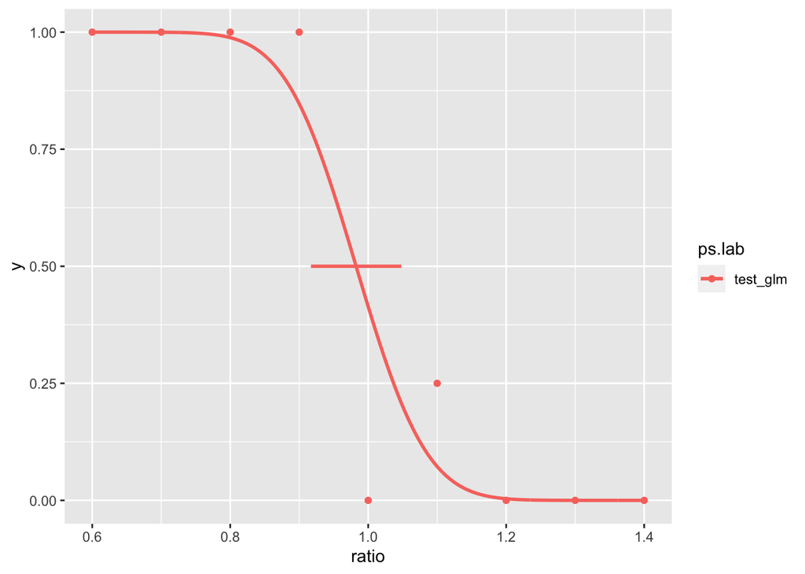

```r
PsychPlot(test_glm, showData = T, ps.lab = "test_glm")
```

## 3 Batched Perceived Action Boundary Calculation

```r
# multiple participants:

# fit_glm_pab <- function(data){
#   mod <- glm(formula = decision ~ ratio,
#                 family = binomial(link = "probit"), data = data)
# beta0 <-coef(mod)[1]
# beta1 <-coef(mod)[2]
# pab= -beta0/beta1
# return(pab)
# }

fit_glm_pab <- function(data){
  mod <- glm(formula = cbind(through, total - through) ~ ratio,
             family = binomial(link = "probit"), data = data)
  psych_delta <- MixedPsy::PsychDelta(mod)
  return(list(pab = psych_delta["pse","Estimate"]))
}


data_by_conditions <-
  response_pab_df %>%
  group_by(group, part_num, direction, session) %>%
  nest()

data_by_conditions <-
  data_by_conditions %>%
  mutate(pab = map(data, fit_glm_pab))

by_subject_pab_df <-
  data_by_conditions %>%
  unnest_longer(pab) %>%
  filter(pab_id == "pab") %>%
  unnest(pab) %>%
  select(-pab_id)
```

```r
# code for saving plots
plots_folder <- here("plots")
for (i in 1:nrow(data_by_conditions)){
  my_plot <- data_by_conditions$pab[[i]]$plot
  part_num <- data_by_conditions$part_num[i]
  group <- data_by_conditions$group[i]
  direction <- data_by_conditions$direction[i]
  filename <- glue("p{part_num}_{group}_{direction}.png")
  #print(filename)
  ggsave(filename = here(plots_folder, filename), plot=my_plot)
}
```

We should be able to take these values and submit them to a lmer

## 4 Results: modeling the Perceived Action Boundary

### 4.1 building the models:

I want to test the following models: - a model with random slopes for session - a model with random intercepts only

```r
pab_mdl <- lmer(pab ~ group * direction * session + (session|part_num),
                data = by_subject_pab_df %>% filter(pab > .5))

rand_int_only_mdl <- lmer(pab ~ group * direction * session + (1|part_num),
                data = by_subject_pab_df %>% filter(pab > .5))
```

### 4.2 Random slopes model results

```r
anova(pab_mdl)
```

```
Type III Analysis of Variance Table with Satterthwaite's method
                          Sum Sq  Mean Sq NumDF  DenDF F value   Pr(>F)
group                   0.041282 0.041282     1 46.868 11.0897 0.001698 **
direction               0.003311 0.003311     1 91.682  0.8896 0.348076
session                 0.005265 0.005265     1 45.858  1.4143 0.240466
group:direction         0.022751 0.022751     1 91.682  6.1117 0.015274 *
group:session           0.009429 0.009429     1 45.858  2.5329 0.118365
direction:session       0.000014 0.000014     1 91.682  0.0038 0.950852
group:direction:session 0.004745 0.004745     1 91.682  1.2748 0.261822
---
Signif. codes:  0 '***' 0.001 '**' 0.01 '*' 0.05 '.' 0.1 ' ' 1
```

The results of the above table suggest a group:direction interaction. Let’s visualize and test

#### 4.2.1 group by direction interaction

```r
emmeans::emmeans(pab_mdl, specs = pairwise ~ direction|group)
```

```
$emmeans
group = Nonpressure Group:
 direction               emmean     SE   df lower.CL upper.CL
 Affordance disappearing  0.910 0.0199 58.6    0.871    0.950
 Affordance emerging      0.897 0.0200 59.3    0.857    0.937

group = Pressure Group:
 direction               emmean     SE   df lower.CL upper.CL
 Affordance disappearing  0.976 0.0193 56.6    0.937    1.015
 Affordance emerging      1.006 0.0193 56.6    0.968    1.045

Results are averaged over the levels of: session
Degrees-of-freedom method: kenward-roger
Confidence level used: 0.95

$contrasts
group = Nonpressure Group:
 contrast                                      estimate     SE   df t.ratio
 Affordance disappearing - Affordance emerging   0.0135 0.0128 91.7   1.054
 p.value
  0.2944

group = Pressure Group:
 contrast                                      estimate     SE   df t.ratio
 Affordance disappearing - Affordance emerging  -0.0302 0.0122 91.0  -2.479
 p.value
  0.0150

Results are averaged over the levels of: session
Degrees-of-freedom method: kenward-roger
```

#### 4.2.2 plot of group by direction interaction

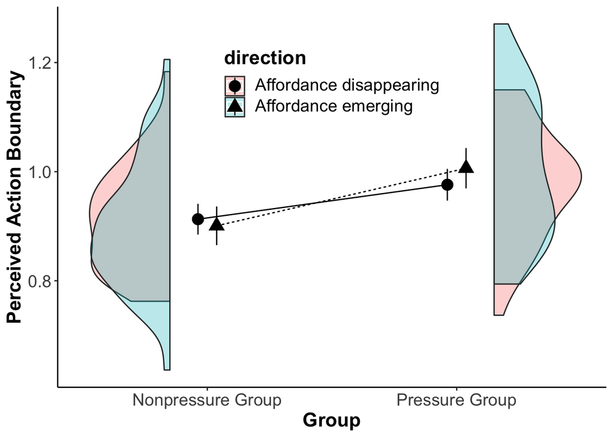

```r
pacman::p_load(ggrain, ggpp, sdamr)

by_subject_pab_df %>%
  filter(pab > .5) %>%
  ggplot(data = , aes(x = group, y=pab, fill = direction, shape = direction)) +
  geom_rain(rain.side = 'f2x2',
            violin.args = list(alpha = .3),
            boxplot.args = list(outlier.shape = NA, color = "white", alpha = 0),
            boxplot.args.pos = list(
              position = ggpp::position_dodgenudge(x = .1),
              width = 0),
            point.args = list(alpha = 0)
            ) +
  stat_summary(fun.data = "mean_cl_normal",
               position = position_dodge(width = .15), size = 1)+
  stat_summary(fun = "mean", geom = "line", aes(lty = direction, group = direction),
               position = position_dodge(width = .15))+
  theme_apa() + xlab("Group") + ylab("Perceived Action Boundary") +
  #scale_shape_discrete(name="Direction", labels=c("Ascending", "Descending")) +
  #scale_fill_manual(values = c("black", "white"), labels = c("Ascending", "Descending")) +
  #scale_fill_discrete(name="Direction", labels=c("Ascending", "Descending")) +
  guides(lty = "none",
         color = "none") +
  theme(legend.position = c(.5, .8))
```

#### 4.2.3 group effect

```r
emmeans::emmeans(pab_mdl, specs = pairwise ~ group)
```

```
$emmeans
 group             emmean     SE   df lower.CL upper.CL
 Nonpressure Group  0.904 0.0189 47.7    0.866    0.942
 Pressure Group     0.991 0.0183 46.1    0.954    1.028

Results are averaged over the levels of: direction, session
Degrees-of-freedom method: kenward-roger
Confidence level used: 0.95

$contrasts
 contrast                           estimate     SE   df t.ratio p.value
 Nonpressure Group - Pressure Group  -0.0875 0.0263 46.9  -3.329  0.0017

Results are averaged over the levels of: direction, session
Degrees-of-freedom method: kenward-roger
```

#### 4.2.4 plot of group effect

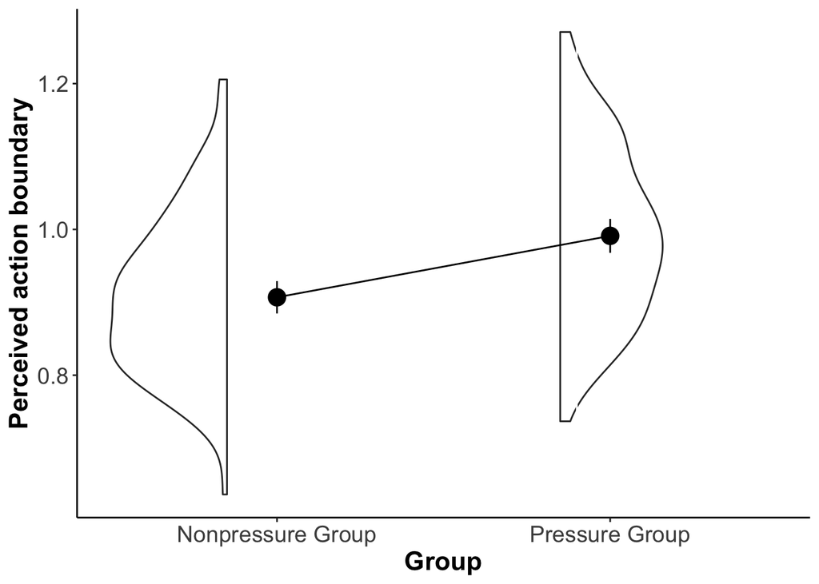

```r
pacman::p_load(ggrain, ggpp, sdamr)

by_subject_pab_df %>%
  filter(pab > .5) %>%
  ggplot(data = , aes(x = group, y=pab)) +
  geom_rain(rain.side = 'f2x2',
            violin.args = list(alpha = .3),
            boxplot.args = list(outlier.shape = NA, color = "white", alpha = 0),
            boxplot.args.pos = list(
              position = ggpp::position_dodgenudge(x = .1),
              width = 0),
            point.args = list(alpha = 0)
            ) +
  stat_summary(fun.data = "mean_cl_normal",
               position = position_dodge(width = .15), size = 1)+
  stat_summary(fun = "mean", geom = "line", aes(group = 1),
               position = position_dodge(width = .15))+
  theme_apa() + xlab("Group") + ylab("Perceived action boundary") +
  #scale_shape_discrete(name="session", labels=c("Session 1", "Session 2")) +
  #scale_fill_manual(values = c("black", "white"), labels = c("Ascending", "Descending")) +
  scale_fill_discrete(name="session", labels=c("Session 1", "Session 2")) +
  guides(lty = "none",
         color = "none") +
  theme(legend.position = c(.4, .8))
```

### 4.3 rand intercepts only model

```r
anova(rand_int_only_mdl)
```

```
Type III Analysis of Variance Table with Satterthwaite's method
                          Sum Sq  Mean Sq NumDF   DenDF F value   Pr(>F)
group                   0.064035 0.064035     1  46.909 11.2723 0.001568 **
direction               0.003189 0.003189     1 136.065  0.5614 0.454985
session                 0.014311 0.014311     1 137.667  2.5192 0.114765
group:direction         0.023131 0.023131     1 136.065  4.0719 0.045569 *
group:session           0.023423 0.023423     1 137.667  4.1233 0.044223 *
direction:session       0.000007 0.000007     1 136.065  0.0012 0.971984
group:direction:session 0.004910 0.004910     1 136.065  0.8643 0.354190
---
Signif. codes:  0 '***' 0.001 '**' 0.01 '*' 0.05 '.' 0.1 ' ' 1
```

```r
emmeans::emmeans(rand_int_only_mdl, specs = pairwise ~ direction|group)
```

```
$emmeans
group = Nonpressure Group:
 direction               emmean     SE   df lower.CL upper.CL
 Affordance disappearing  0.910 0.0204 64.7    0.869    0.951
 Affordance emerging      0.896 0.0205 65.5    0.855    0.937

group = Pressure Group:
 direction               emmean     SE   df lower.CL upper.CL
 Affordance disappearing  0.976 0.0198 62.8    0.936    1.016
 Affordance emerging      1.006 0.0198 62.8    0.967    1.046

Results are averaged over the levels of: session
Degrees-of-freedom method: kenward-roger
Confidence level used: 0.95

$contrasts
group = Nonpressure Group:
 contrast                                      estimate     SE  df t.ratio
 Affordance disappearing - Affordance emerging   0.0139 0.0158 136   0.876
 p.value
  0.3827

group = Pressure Group:
 contrast                                      estimate     SE  df t.ratio
 Affordance disappearing - Affordance emerging  -0.0302 0.0151 136  -2.007
 p.value
  0.0468

Results are averaged over the levels of: session
Degrees-of-freedom method: kenward-roger
```

#### 4.3.2 plot of group by session interaction

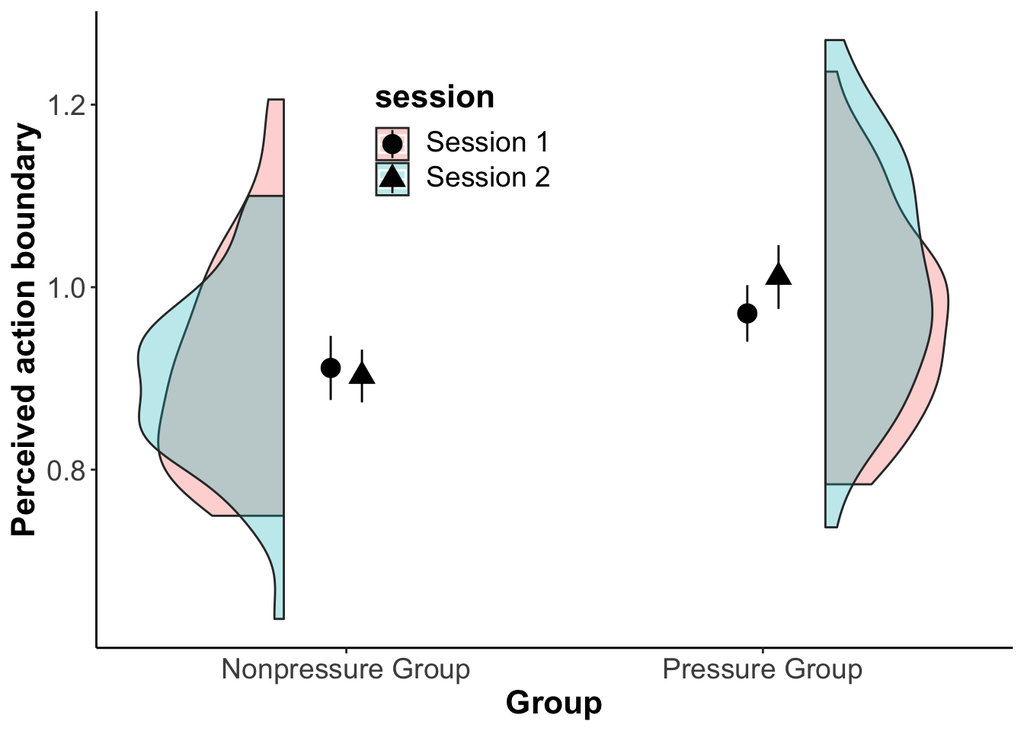

```r
pacman::p_load(ggrain, ggpp, sdamr)

by_subject_pab_df %>%
  filter(pab > .5) %>%
  ggplot(data = , aes(x = group, y=pab, fill = session, shape = session)) +
  geom_rain(rain.side = 'f2x2',
            violin.args = list(alpha = .3),
            boxplot.args = list(outlier.shape = NA, color = "white", alpha = 0),
            boxplot.args.pos = list(
              position = ggpp::position_dodgenudge(x = .1),
              width = 0),
            point.args = list(alpha = 0)
            ) +
  stat_summary(fun.data = "mean_cl_normal",
               position = position_dodge(width = .15), size = 1)+
  theme_apa() + xlab("Group") + ylab("Perceived action boundary") +
  #scale_shape_discrete(name="Direction", labels=c("Ascending", "Descending")) +
  #scale_fill_manual(values = c("black", "white"), labels = c("Ascending", "Descending")) +
  #scale_fill_discrete(name="Direction", labels=c("Ascending", "Descending")) +
  guides(lty = "none",
         color = "none") +
  theme(legend.position = c(.4, .8))
```

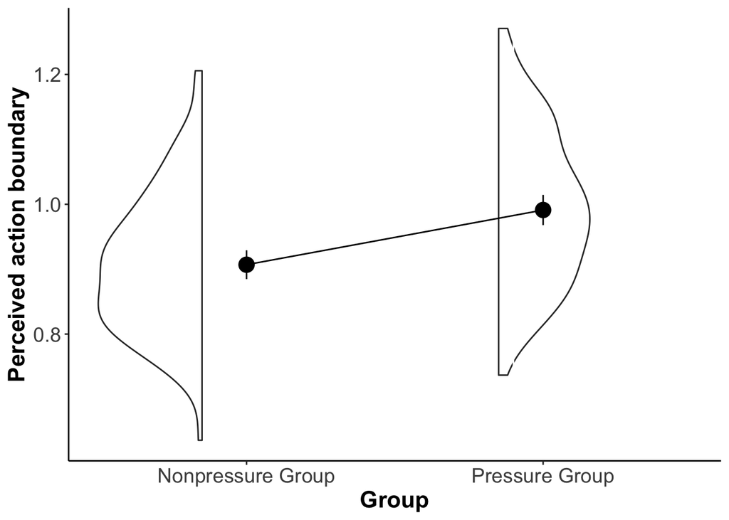

```r
pacman::p_load(ggrain, ggpp, sdamr)

by_subject_pab_df %>%
  filter(pab > .5) %>%
  ggplot(data = , aes(x = group, y=pab)) +
  geom_rain(rain.side = 'f2x2',
            violin.args = list(alpha = .3),
            boxplot.args = list(outlier.shape = NA, color = "white", alpha = 0),
            boxplot.args.pos = list(
              position = ggpp::position_dodgenudge(x = .1),
              width = 0),
            point.args = list(alpha = 0)
            ) +
  stat_summary(fun.data = "mean_cl_normal",
               position = position_dodge(width = .15), size = 1)+
  stat_summary(fun = "mean", geom = "line", aes(group = 1),
               position = position_dodge(width = .15))+
  theme_apa() + xlab("Group") + ylab("Perceived action boundary") +
  #scale_shape_discrete(name="session", labels=c("Session 1", "Session 2")) +
  #scale_fill_manual(values = c("black", "white"), labels = c("Ascending", "Descending")) +
  scale_fill_discrete(name="session", labels=c("Session 1", "Session 2")) +
  guides(lty = "none",
         color = "none") +
  theme(legend.position = c(.4, .8))
```

```r
emmeans::emmeans(pab_mdl, specs = pairwise ~ group)
```

```
$emmeans
 group             emmean     SE   df lower.CL upper.CL
 Nonpressure Group  0.904 0.0189 47.7    0.866    0.942
 Pressure Group     0.991 0.0183 46.1    0.954    1.028

Results are averaged over the levels of: direction, session
Degrees-of-freedom method: kenward-roger
Confidence level used: 0.95

$contrasts
 contrast                           estimate     SE   df t.ratio p.value
 Nonpressure Group - Pressure Group  -0.0875 0.0263 46.9  -3.329  0.0017

Results are averaged over the levels of: direction, session
Degrees-of-freedom method: kenward-roger
```

```r
choice_mdl <- lmer(choice~group*session + (session|part_num), data = filtered_data_raw_df)
summary(choice_mdl)
```

```
Linear mixed model fit by REML. t-tests use Satterthwaite's method [
lmerModLmerTest]
Formula: choice ~ group * session + (session | part_num)
   Data: filtered_data_raw_df

REML criterion at convergence: 5925.8

Scaled residuals:
    Min      1Q  Median      3Q     Max
-0.7955 -0.5302 -0.4333 -0.2941  2.3595

Random effects:
 Groups   Name             Variance  Std.Dev. Corr
 part_num (Intercept)      0.0026433 0.05141
          sessionSession 2 0.0002249 0.01500  1.00
 Residual                  0.1506811 0.38818
Number of obs: 6174, groups:  part_num, 49

Fixed effects:
                                       Estimate Std. Error         df t value
(Intercept)                           2.022e-01  1.500e-02  5.141e+01  13.473
groupPressure Group                  -1.117e-02  2.055e-02  4.866e+01  -0.543
sessionSession 2                     -2.895e-03  1.501e-02  5.031e+02  -0.193
groupPressure Group:sessionSession 2 -5.786e-04  2.043e-02  4.181e+02  -0.028
                                     Pr(>|t|)
(Intercept)                            <2e-16 ***
groupPressure Group                     0.589
sessionSession 2                        0.847
groupPressure Group:sessionSession 2    0.977
---
Signif. codes:  0 '***' 0.001 '**' 0.01 '*' 0.05 '.' 0.1 ' ' 1

Correlation of Fixed Effects:
            (Intr) grpPrG sssnS2
grpPrssrGrp -0.730
sessinSssn2 -0.359  0.262
grpPGrp:sS2  0.263 -0.335 -0.735
optimizer (nloptwrap) convergence code: 0 (OK)
boundary (singular) fit: see help('isSingular')
```

```r
#choice=1 (incorrect); choice= 0 (correct)
```

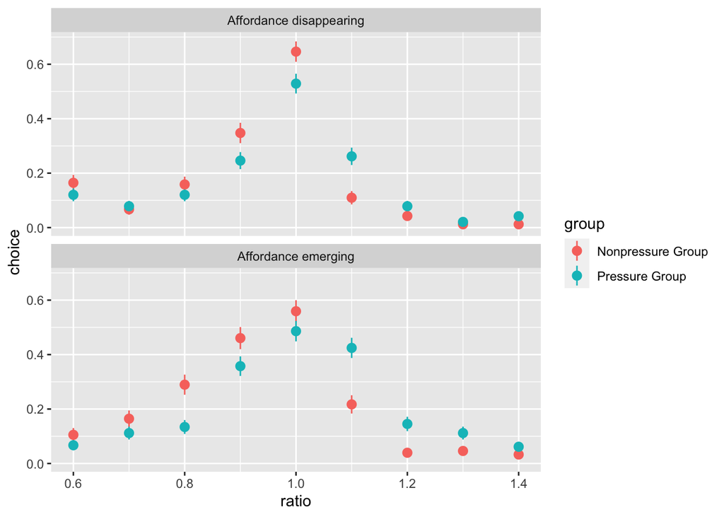

```r
ggplot(filtered_data_raw_df, aes(x = ratio, y = choice, col = group)) +
  stat_summary(fun.data = "mean_se") +
  facet_wrap(~direction, ncol = 1)
```